# OFE Analysis of strip trials

Fiona H Evans

6 June 2018

## Introduction

This document descfibes analyses of an onfarm experiment conducted in Western Australia in 2016, focusing on the potassium (K) trial data.

## Data

The data provided had been previously interpolated to the same locations as the yield monitor data. For this report, the data have been ‘anonymised’ by rescaling the Longitudes and Latitudes. Data are provided in the file ‘TrialData.Rdata’:

- Data frame **dat** contains original data with columns:
  - Longitude
  - Latitude
  - Barley.Yield
  - DualEM.Shallow
  - Radiometrics.Potassium
  - Radiometrics.Thorium
  - P.Trial: phosphorus trial rates of 0, 13, 25, 38, 50, 63 and 75 and four zones over the southern part of the paddock treated with rates of 30, 40, 50 and 60
  - K.Trial: potassium trial rates of 0, 15, 30 and 60 and three zones over the southern part of the paddock treated with rates of 0, 15 and 30
  - seedRate.Trial: seeding trial rates of 50, 70, 90 and 110, with a rate of 70 used for the remainder of the paddock
- Data frame **Kdat** is the data for the K trial only
- rasterStack **rdat** is a 12m by 12m (the header width) grid of the paddock data created by fishnetting (ie. taking the mean of all points within the cell)

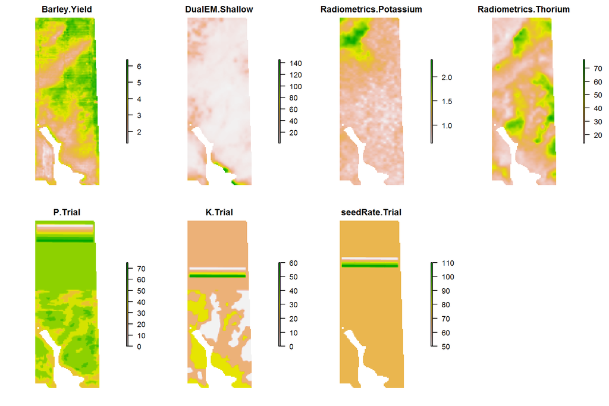

```r
load("TrialData.Rdata")

if("raster" %in% rownames(installed.packages()) == FALSE) install.packages("raster")
library(raster)

plot(rdat[[3:9]], axes=F, box=F, nr=2, nc=4)
```

The extracted K trial dat are shown below. In the K Trial: colour red shows a zero rate, green shows a rate of 15 and cyan shows a rate of 30.

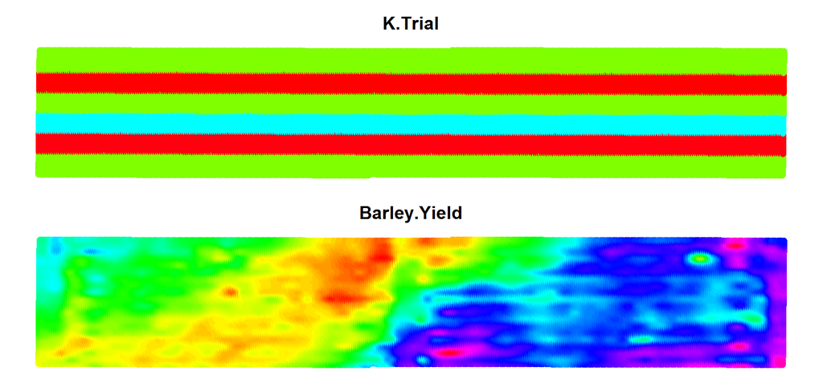

```r
if("agric" %in% rownames(installed.packages()) == FALSE) install_github("fionahevans/agric")
library(agric)

par(mfrow=c(2,1))
par(mai=c(0.1, 0.1, 0.5, 0.1))
with(Kdat, plot(Longitude, Latitude, col=color.of(Kdat$K.Trial), pch=16, axes=F, xlab="", ylab="", main="K.Trial"))
with(Kdat, plot(Longitude, Latitude, col=color.of(Kdat$Barley.Yield), pch=16, axes=F, xlab="", ylab="",
                main="Barley.Yield"))
```

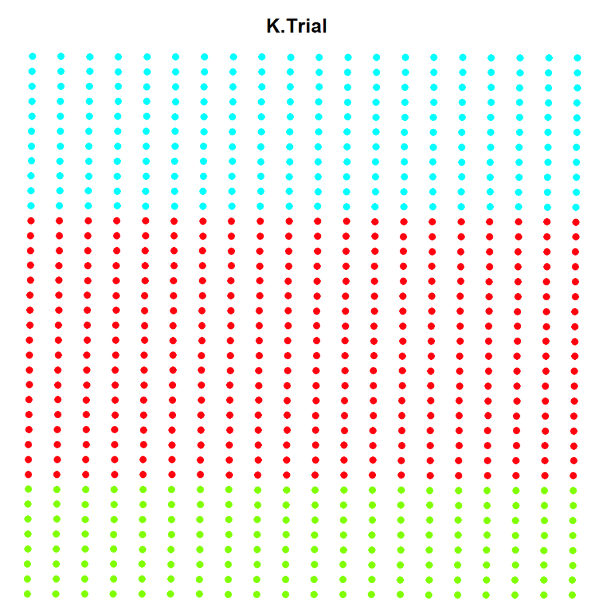

```r
par(mfrow=c(1,1))
par(mai=c(0.1, 0.1, 0.5, 0.1))
with(Kdat, plot(Longitude, Latitude, col=color.of(Kdat$K.Trial), pch=16, axes=F, xlab="", ylab="", xlim=c(2, 5), ylim=c(115, 120), main="K.Trial"))
```

## Data Analysis

### Anova

```r
# First make factor for K trial rates
Kdat$K <- as.factor(Kdat$K.Trial)

# Anova
a <- aov(Barley.Yield ~ K, data=Kdat)
TukeyHSD(a)
```

```
##   Tukey multiple comparisons of means
##     95% family-wise confidence level
##
## Fit: aov(formula = Barley.Yield ~ K, data = Kdat)
##
## $K
##              diff         lwr         upr     p adj
## 15-0   0.14002504  0.10563356  0.17441652 0.0000000
## 30-0   0.05993198  0.01754096  0.10232301 0.0016014
## 60-0   0.16410607  0.12171504  0.20649710 0.0000000
## 30-15 -0.08009305 -0.11448453 -0.04570158 0.0000000
## 60-15  0.02408103 -0.01031045  0.05847251 0.2738256
## 60-30  0.10417408  0.06178306  0.14656511 0.0000000
```

Boxplots of barley yields by K rate show increasing yield with K rates, but density plots show large deviations from normality. For rates 0 and 15, the desnities look trimodal. For rates 30 and 60, the densities look bimodal.

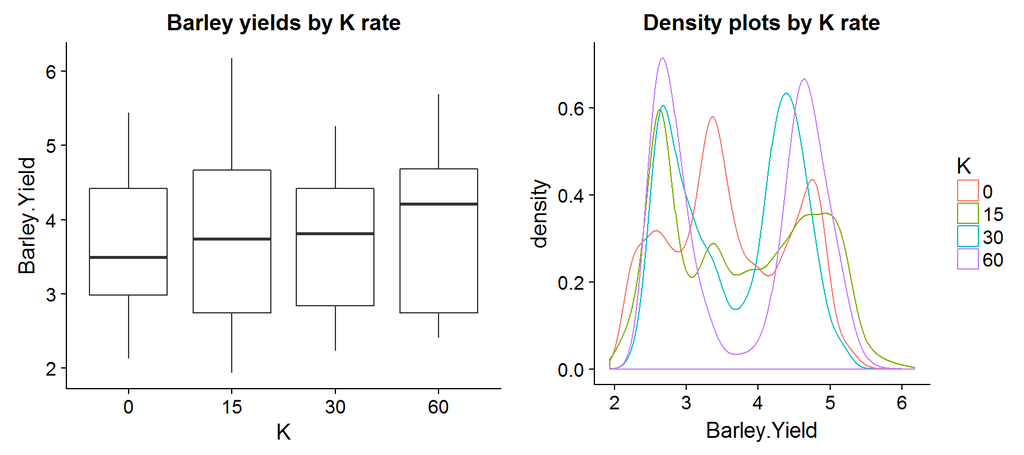

```r
if("ggplot2" %in% rownames(installed.packages()) == FALSE) install.packages("ggplot2")
if("cowplot" %in% rownames(installed.packages()) == FALSE) install.packages("cowplot")
library(ggplot2)
library(cowplot)

gg1 <- ggplot(Kdat, aes(y = Barley.Yield, x = K)) + geom_boxplot() +
  ggtitle("Barley yields by K rate")

# Check the data for normality
gg2 <- ggplot(Kdat, aes(Barley.Yield, colour=K, group=K)) + geom_density() +
  ggtitle("Density plots by K rate")

plot_grid(gg1, gg2)
```

One way to handle this might be to extract regions from within the strips that have normally distributed yields for each rate and then conduct the Anova using that data only. TNote that this would give no insight about the underlying causes of different yields in different regions.

The strips in this trial are wide, each is measured by around 18 runs of the header. So we do not make further attempts to manually extract data from each strip.

```r
# Fit Gaussian mixture model with 3 components
if("mixtools" %in% rownames(installed.packages()) == FALSE) install.packages("mixtools")
library(mixtools)
x = Kdat$Barley.Yield
mixmdl = normalmixEM(x, k=3)
```

```
## number of iterations= 194
```

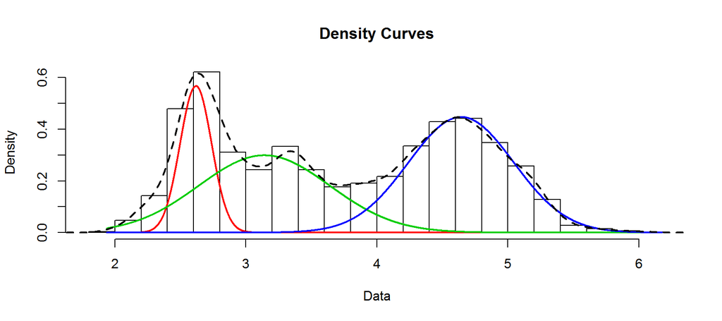

```r
plot(mixmdl, which=2)
lines(density(x), lty=2, lwd=2)
```

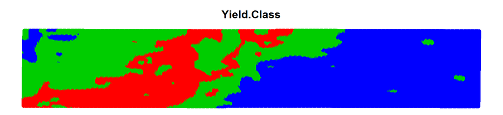

```r
# Get the most likely yield class
f <- function(pixel, ...) {
  pixel <- as.vector(pixel)
  which(pixel == max(pixel))
}

Kdat$Yield.Class = as.factor(apply(mixmdl$posterior, 1, f))
# Rasterize and plot
mymode <- function(x, ...)  {
  ux <- unique(x)
  ux[which.max(tabulate(match(x, ux)))]
}

par(mai=c(0.1, 0.1, 0.5, 0.1))
with(Kdat, plot(Longitude, Latitude, col=as.numeric(Yield.Class)+1, pch=16, axes=F, xlab="", ylab="",
                main="Yield.Class"))
```

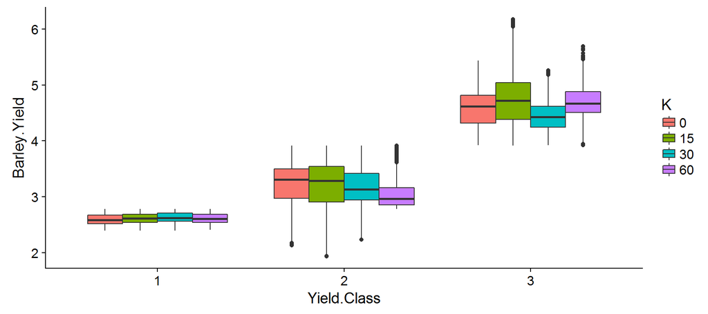

```r
# Plot yields by class and K rate
ggplot(Kdat, aes(y = Barley.Yield, x = Yield.Class, fill = K)) + geom_boxplot()
```

The mapped yield classes could be optimised further, but we can see now that there is a significant (check the Anova) difference between the three yield classes, and that each responds differently to K applications - and only the lowest yielding areas respond as would be expected (increasing yields with increasing rates up to a maximum yield). The medium-yielding ares have a negative response to K, and the higher yielding areas have a mixed response to K.

Of course, this classification of yield is based only on a single year and may not be a good way of zoning the trial.

### Generalised additive models

Fitting a generalized additive model (GAM) to the trial data; however, the residuals largely correspond to the yield data.

```r
if("mgcv" %in% rownames(installed.packages()) == FALSE) install.packages("mgcv")
library(mgcv)

g1 <- gam(Barley.Yield ~ s(K.Trial, k=3) , data=Kdat)
summary(g1)
```

```
##
## Family: gaussian
## Link function: identity
##
## Formula:
## Barley.Yield ~ s(K.Trial, k = 3)
##
## Parametric coefficients:
##             Estimate Std. Error t value Pr(>|t|)
## (Intercept) 3.728634   0.004706   792.2   <2e-16 ***
## ---
## Signif. codes:  0 '***' 0.001 '**' 0.01 '*' 0.05 '.' 0.1 ' ' 1
##
## Approximate significance of smooth terms:
##              edf Ref.df     F  p-value
## s(K.Trial) 1.919  1.993 24.62 1.27e-11 ***
## ---
## Signif. codes:  0 '***' 0.001 '**' 0.01 '*' 0.05 '.' 0.1 ' ' 1
##
## R-sq.(adj) =  0.00126   Deviance explained = 0.131%
## GCV = 0.88926  Scale est. = 0.88919   n = 40143
```

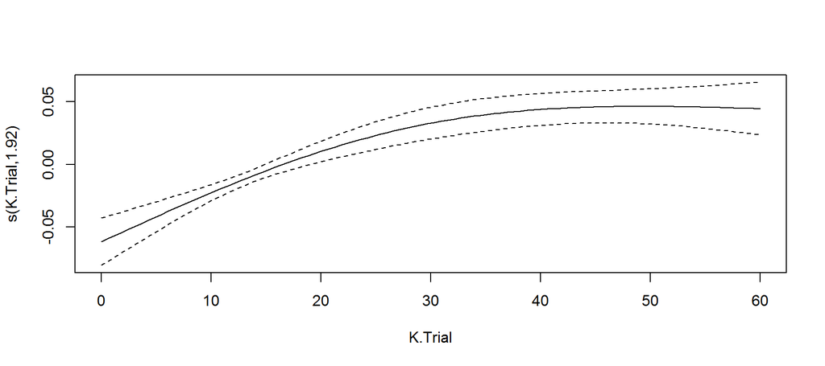

```r
p1 <- predict(g1, newdata=Kdat)
plot(g1)
```

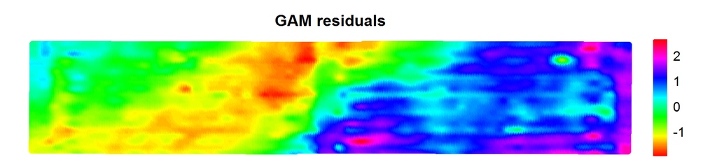

```r
par(mai=c(0.1, 0.1, 0.5, 0.8))
with(Kdat, plot(Longitude, Latitude, col=color.of(Kdat$Barley.Yield-p1), pch=16, axes=F, xlab="", ylab="",
                main="GAM residuals"))
legend.col(col = rainbow(100), lev = Kdat$Barley.Yield-p1)
```

Adding a term to the model to account for spatial variability reverse the fitted response to K and reduces the spatial coherence of the residuals.

```r
g2 <- gam(Barley.Yield ~ s(K.Trial, k=3) + s(Longitude, Latitude), data=Kdat)
summary(g2)
```

```
##
## Family: gaussian
## Link function: identity
##
## Formula:
## Barley.Yield ~ s(K.Trial, k = 3) + s(Longitude, Latitude)
##
## Parametric coefficients:
##             Estimate Std. Error t value Pr(>|t|)
## (Intercept) 3.728634   0.001019    3658   <2e-16 ***
## ---
## Signif. codes:  0 '***' 0.001 '**' 0.01 '*' 0.05 '.' 0.1 ' ' 1
##
## Approximate significance of smooth terms:
##                          edf Ref.df        F p-value
## s(K.Trial)             1.933  1.995    90.28  <2e-16 ***
## s(Longitude,Latitude) 28.987 29.000 28128.52  <2e-16 ***
## ---
## Signif. codes:  0 '***' 0.001 '**' 0.01 '*' 0.05 '.' 0.1 ' ' 1
##
## R-sq.(adj) =  0.953   Deviance explained = 95.3%
## GCV = 0.041737  Scale est. = 0.041704  n = 40143
```

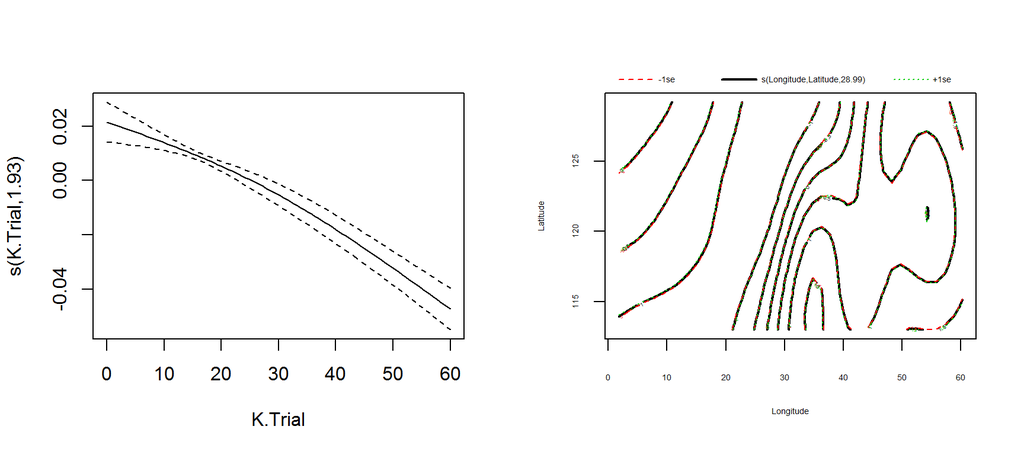

```r
p2 <- predict(g2, newdata=Kdat)
plot(g2, pages=1)
```

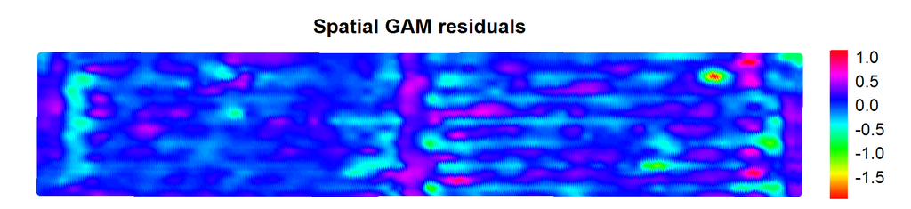

```r
par(mai=c(0.1, 0.1, 0.5, 0.8))
with(Kdat, plot(Longitude, Latitude, col=color.of(Kdat$Barley.Yield-p2), pch=16, axes=F, xlab="", ylab="",
                main="Spatial GAM residuals"))
legend.col(col = rainbow(100), lev = Kdat$Barley.Yield-p2)
```

### Geographically weighted regression

There are several R packages for performing geographically weighted regression. When I have attempted to use the package ‘spgwr’ with large data sets (n=5000 or more), it takes forever to run. I recommend using package ‘GWmodel’.

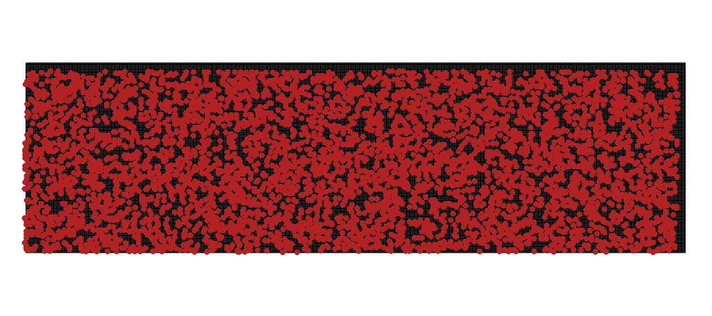

```r
# Fit Gaussian mixture model with 3 components
if("GWmodel" %in% rownames(installed.packages()) == FALSE) install.packages("GWmodel")
library(GWmodel)
# The following has been adapted from https://rpubs.com/chrisbrunsdon/101305

# Take a randpom sample of 5000 data points and create SpatialPointsDataFrame
samp <- samp.sp <- Kdat[sample(nrow(Kdat), 5000),]
coordinates(samp.sp) <- ~Longitude + Latitude

# Us ethe bounding box to create a fine-scale grid that covers the data
# bbox(samp.sp)
# min       max
# Longitude   1.81321  60.23419
# Latitude  112.98711 129.20555

cs <- c(0.1,0.1)
cc <- c(2,113)
cd <- c(59,17)/cs
grd <- SpatialGrid(GridTopology(cc, cs, cd))

par(mai=c(0,0,0,0))
plot(grd)
plot(samp.sp, pch=16, col='firebrick',add=TRUE)
```

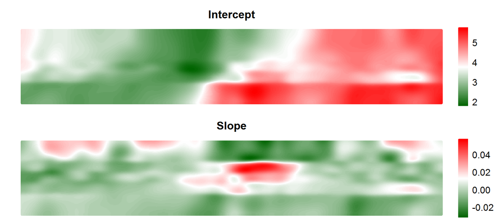

```r
# Calculate distances - this takes aound 30 seconds on my laptop
DM <- gw.dist(dp.locat=coordinates(samp.sp),
              rp.locat=coordinates(grd))

# Do GWR
gwr.res <- gwr.basic(Barley.Yield ~ K.Trial, data=samp.sp,
                     regression.points=grd, bw=1,
                     dMat=DM, kernel='gaussian')

coefs <- as.data.frame(gwr.res$SDF)

par(mfrow=c(2,1))
par(mai=c(0.1, 0.1, 0.5, 0.8))
colr <- two.colors.old(100)
with(coefs, plot(s1, s2, col=color.of(coefs[, "Intercept"], col=colr),
                 pch=20, axes=F, xlab="", ylab="", main="Intercept"))
legend.col(col = colr, lev = coefs[, "Intercept"])
with(coefs, plot(s1, s2, col=color.of(coefs[, "K.Trial"], col=colr),
              pch=20, axes=F, xlab="", ylab="", main="Slope"))
legend.col(col = colr, lev = coefs[, "K.Trial"])
```

It is hard to compare the response to K with varying intercepts, so perfrom GWR with a fixed intercept.

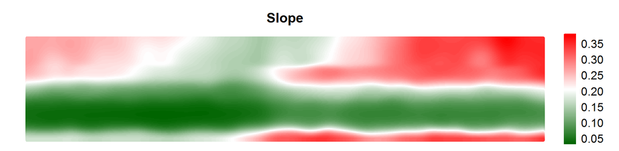

```r
# Set intercept
gwr.res2 <- gwr.basic(Barley.Yield ~ 0 + K.Trial, data=samp.sp,
                     regression.points=grd, bw=1,
                     dMat=DM, kernel='gaussian')

coefs2 <- as.data.frame(gwr.res2$SDF)

par(mai=c(0.1, 0.1, 0.5, 0.8))
with(coefs2, plot(s1, s2, col=color.of(coefs2[, "K.Trial"], col=colr),
                 pch=20, axes=F, xlab="", ylab="", main="Slope"))
legend.col(col = colr, lev = coefs2[, "K.Trial"])
```

### Additional data - Gamma radiometrics and shallow EM

#### Clustering

Discussed above - Gaussian mixture models can be applied to multivariate data (covariates) to cluster data into zones.

#### GAMs

Discussed above - can add spline terms for additional covariates.

#### Random forests

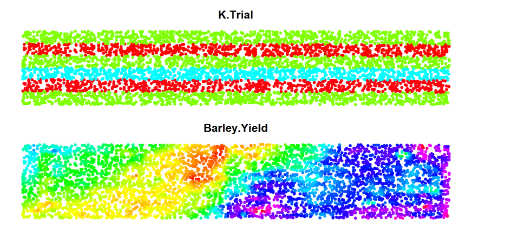

```r
if("randomForest" %in% rownames(installed.packages()) == FALSE) install.packages("GWmodel")
library(randomForest)

# randomForest library does not handle missing data, so use complete cases only
rfsamp <- samp[complete.cases(subset(samp,
              select=c("Longitude", "Latitude", "Barley.Yield",
                       "K.Trial", "DualEM.Shallow",
                      "Radiometrics.Potassium",
                       "Radiometrics.Thorium"))),]

par(mfrow=c(2,1))
par(mai=c(0.1, 0.1, 0.5, 0.8))
with(rfsamp, plot(Longitude, Latitude, col=color.of(rfsamp$K.Trial), pch=20, axes=F, xlab="", ylab="",
                main="K.Trial"))
with(rfsamp, plot(Longitude, Latitude, col=color.of(rfsamp$Barley.Yield), pch=20, axes=F, xlab="", ylab="",
                main="Barley.Yield"))
```

```r
system.time(
r0 <- randomForest(Barley.Yield ~ K.Trial + DualEM.Shallow + Radiometrics.Potassium + Radiometrics.Thorium,  mtry=4, data=rfsamp))
```

```
##    user  system elapsed
##   47.66    0.02   48.10
```

```r
# user  system elapsed
# 19.04    0.07   19.34
print(r0)
```

```
##
## Call:
##  randomForest(formula = Barley.Yield ~ K.Trial + DualEM.Shallow +      Radiometrics.Potassium + Radiometrics.Thorium, data = rfsamp,      mtry = 4)
##                Type of random forest: regression
##                      Number of trees: 500
## No. of variables tried at each split: 4
##
##           Mean of squared residuals: 0.08454839
##                     % Var explained: 90.43
```

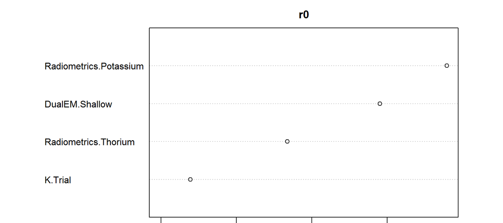

```r
par(mfrow=c(1,1))

varImpPlot(r0)
```

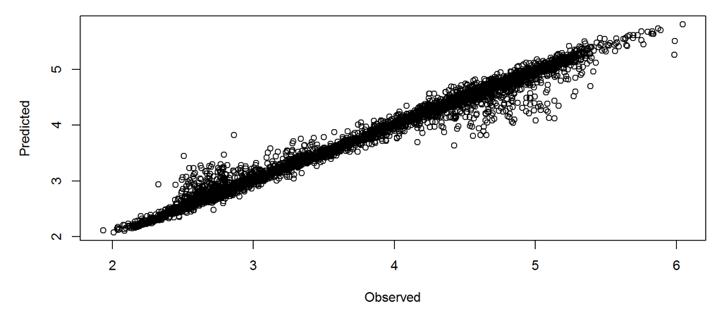

```r
p <- predict(r0, newdata=rfsamp)

# Plot observed vs predicted
par(mai=c(1, 1, 0.2, 0.2))
plot(rfsamp$Barley.Yield, p, xlab="Observed", ylab="Predicted")
```

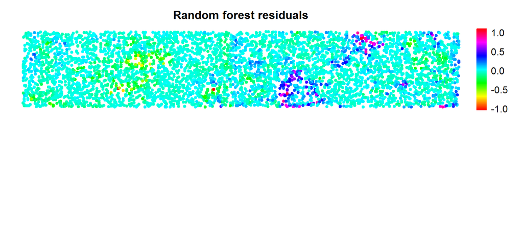

```r
# Plot residuals
par(mfrow=c(2,1))
par(mai=c(0.1, 0.1, 0.5, 0.8))
with(rfsamp, plot(Longitude, Latitude, col=color.of(rfsamp$Barley.Yield-p), pch=20, axes=F, xlab="", ylab="",
                  main="Random forest residuals"))
legend.col(col = rainbow(100), lev = rfsamp$Barley.Yield-p)
```

## Conclusions

TBC…